# HW 10 - PCR data

Keanu Rochette

2025-04-06

## Load libraries

```r
# Data manipulation and visualization
library(tidyverse)
library(here)
library(janitor)
library(gt)
library(gtExtras)
library(grid)
library(patchwork)

# Data analysis/statistics
#library(glmmTMB)
library(car) #ANOVA
library(ggResidpanel) #residual panel
library(ggeffects)
library(effects) #dependency for ggeffects
library(MuMIn)
#library(arm) #discrete.histogram() function
#library(MASS) #required for arm package
```

## Load data

```r
alawai <- read_csv(here("HW10", "data", "AlaWai_Bottles.csv"))
alawai <- clean_names(alawai)
colnames(alawai)
```

```
##  [1] "sample_name"         "date"                "month"
##  [4] "month_year"          "start_time"          "end_time"
##  [7] "start_time_epoch"    "end_time_epoch"      "sample_label"
## [10] "bottle_number"       "sample_id"           "site"
## [13] "sample_depth"        "season"              "tide_direction"
## [16] "tide_type"           "sampling_direction"  "depth"
## [19] "pressure"            "latitude"            "longitude"
## [22] "distance"            "tide"                "vvh_a"
## [25] "total_prokaryotes"   "lab_chla"            "rainfall"
## [28] "rainfall_5day"       "air_temp"            "air_temp_max"
## [31] "discharge"           "discharge_3day"      "total_n"
## [34] "n_ox"                "nh3"                 "tdn"
## [37] "pon"                 "don"                 "total_p"
## [40] "phosphate"           "dop"                 "silicate"
## [43] "doc"                 "poc"                 "toc"
## [46] "chlorophyll_raw"     "chlorophyll"         "labp_h"
## [49] "lab_conductivity"    "lab_salinity"        "conductivity"
## [52] "density"             "salinity"            "water_temp"
## [55] "o2sat"               "o2concentration_raw" "o2conc"
## [58] "turbidity_raw"       "turbidity"           "m_c"
## [61] "bix"                 "hix"                 "fi"
## [64] "uv_humic_like"       "marine_humic_like"   "visible_humic_like"
## [67] "tryptophan_like"     "tyrosine_like"       "phenylalanine_like"
## [70] "fulvic_acid_like"    "optical_brighteners" "diesel_band_ii"
## [73] "petroleum_like"      "lignin_like"
```

## Question 1

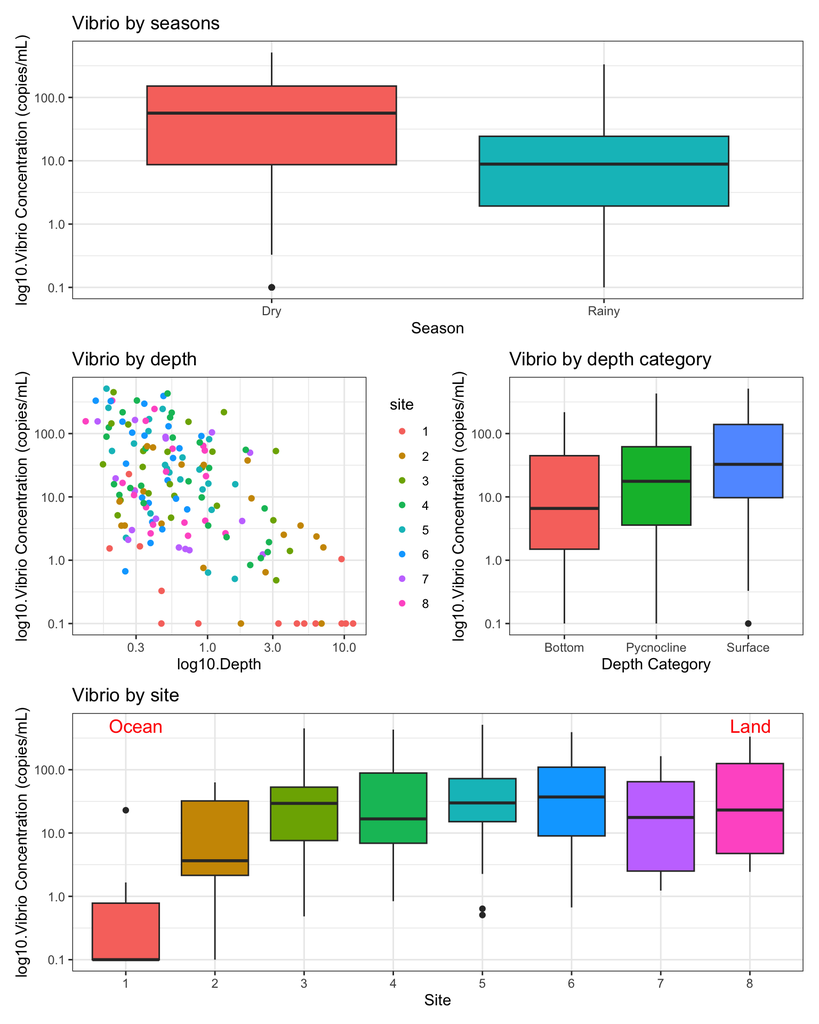

```r
Vxseason <- ggplot(alawai, aes(season, vvh_a, fill = season)) +
  geom_boxplot()+
  labs(title= "Vibrio by seasons",
       x= "Season", y = "log10.Vibrio Concentration (copies/mL)")+
  scale_y_log10()+
  theme_bw() +
  theme(legend.position = "none")

Vxdepth <- alawai %>%  mutate(site = factor(site)) %>%
  ggplot( aes(depth, vvh_a, color = site)) +
  geom_point()+
  labs(title= "Vibrio by depth",
       x= "log10.Depth", y = "log10.Vibrio Concentration (copies/mL)")+
  scale_x_log10()+
  scale_y_log10()+
  theme_bw()

Vxsampledepth <- ggplot(alawai, aes(sample_depth, vvh_a, fill = sample_depth)) +
  geom_boxplot()+
  labs(title= "Vibrio by depth category",
       x= "Depth Category", y = "log10.Vibrio Concentration (copies/mL)")+
  scale_y_log10()+
  theme_bw()+
  theme(legend.position = "none")

sea_lab <- grobTree(textGrob("Ocean", x=0.05,  y=0.95, hjust=0,
  gp=gpar(col="red", fontsize=13)))
land_lab <- grobTree(textGrob("Land", x=0.9,  y=0.95, hjust=0,
  gp=gpar(col="red", fontsize=13)))

Vxsite <- alawai %>% mutate(site = factor(site)) %>%
  ggplot(aes(site, vvh_a, fill = site)) +
  geom_boxplot()+
  labs(title= "Vibrio by site",
       x= "Site", y = "log10.Vibrio Concentration (copies/mL)")+
  annotation_custom(sea_lab)+
  annotation_custom(land_lab)+
 scale_y_log10()+
  theme_bw()+
  theme(legend.position = "none")

Vxseason / (Vxdepth + Vxsampledepth)/ Vxsite
```

### Model setup

```r
model0 <- lm(vvh_a ~ sample_depth + site + season+
               sample_depth:site + sample_depth:season +
               site: season, data = alawai)
summary(model0)
```

```
##
## Call:
## lm(formula = vvh_a ~ sample_depth + site + season + sample_depth:site +
##     sample_depth:season + site:season, data = alawai)
##
## Residuals:
##     Min      1Q  Median      3Q     Max
## -176.33  -37.12  -13.40    8.25  355.74
##
## Coefficients:
##                                    Estimate Std. Error t value Pr(>|t|)
## (Intercept)                           1.839     33.188   0.055   0.9559
## sample_depthPycnocline               39.673     42.011   0.944   0.3464
## sample_depthSurface                  56.642     41.270   1.372   0.1718
## site                                  9.137      6.131   1.490   0.1381
## seasonRainy                          16.354     36.710   0.445   0.6566
## sample_depthPycnocline:site           3.240      7.451   0.435   0.6642
## sample_depthSurface:site             10.497      7.451   1.409   0.1608
## sample_depthPycnocline:seasonRainy  -42.133     32.285  -1.305   0.1937
## sample_depthSurface:seasonRainy     -76.873     32.085  -2.396   0.0177 *
## site:seasonRainy                    -10.746      5.996  -1.792   0.0750 .
## ---
## Signif. codes:  0 '***' 0.001 '**' 0.01 '*' 0.05 '.' 0.1 ' ' 1
##
## Residual standard error: 84.36 on 161 degrees of freedom
##   (42 observations deleted due to missingness)
## Multiple R-squared:  0.2918, Adjusted R-squared:  0.2522
## F-statistic:  7.37 on 9 and 161 DF,  p-value: 5.743e-09
```

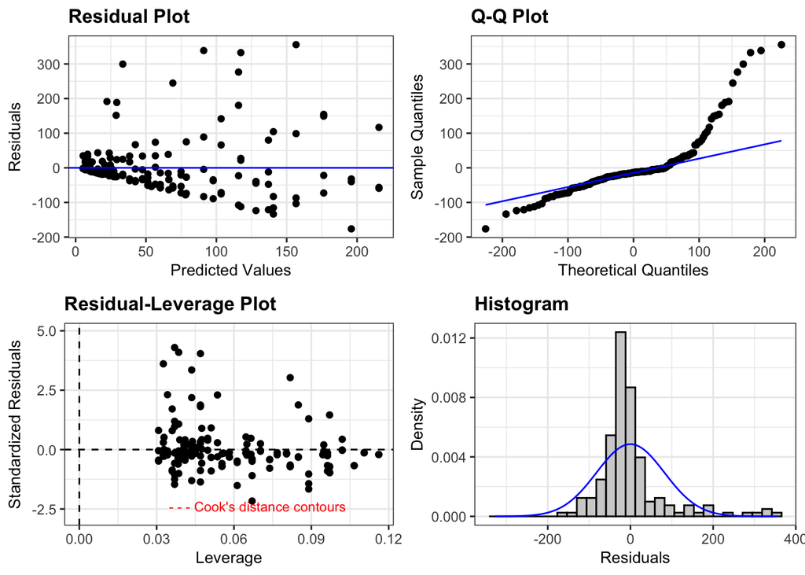

```r
resid_panel(model0, plots = c("resid", "qq", "lev", "hist"))
```

```r
logmodel0 <- lm(log(vvh_a) ~ sample_depth + site + season+
               sample_depth:site + sample_depth:season +
               site: season, data = alawai)
summary(logmodel0)
```

```
##
## Call:
## lm(formula = log(vvh_a) ~ sample_depth + site + season + sample_depth:site +
##     sample_depth:season + site:season, data = alawai)
##
## Residuals:
##     Min      1Q  Median      3Q     Max
## -4.8356 -1.0588 -0.0007  1.3177  3.8676
##
## Coefficients:
##                                    Estimate Std. Error t value Pr(>|t|)
## (Intercept)                         -0.4249     0.6852  -0.620  0.53602
## sample_depthPycnocline               1.5700     0.8674   1.810  0.07214 .
## sample_depthSurface                  2.5304     0.8521   2.970  0.00344 **
## site                                 0.6599     0.1266   5.213 5.63e-07 ***
## seasonRainy                         -0.4006     0.7579  -0.529  0.59788
## sample_depthPycnocline:site         -0.1765     0.1538  -1.147  0.25300
## sample_depthSurface:site            -0.2324     0.1538  -1.511  0.13278
## sample_depthPycnocline:seasonRainy  -0.1711     0.6666  -0.257  0.79780
## sample_depthSurface:seasonRainy      0.1221     0.6624   0.184  0.85402
## site:seasonRainy                    -0.2526     0.1238  -2.040  0.04294 *
## ---
## Signif. codes:  0 '***' 0.001 '**' 0.01 '*' 0.05 '.' 0.1 ' ' 1
##
## Residual standard error: 1.742 on 161 degrees of freedom
##   (42 observations deleted due to missingness)
## Multiple R-squared:  0.3835, Adjusted R-squared:  0.349
## F-statistic: 11.13 on 9 and 161 DF,  p-value: 2.044e-13
```

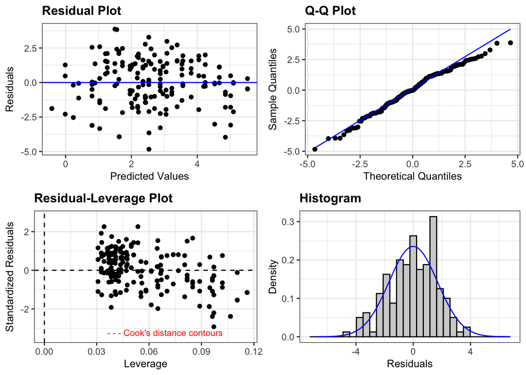

```r
resid_panel(logmodel0, plots = c("resid", "qq", "lev", "hist"))
```

```r
Anova(logmodel0)
```

```
## Anova Table (Type II tests)
##
## Response: log(vvh_a)
##                     Sum Sq  Df F value    Pr(>F)
## sample_depth         64.85   2 10.6888 4.378e-05 ***
## site                119.43   1 39.3728 3.107e-09 ***
## season              107.98   1 35.5991 1.492e-08 ***
## sample_depth:site     7.40   2  1.2193   0.29814
## sample_depth:season   0.64   2  0.1063   0.89925
## site:season          12.63   1  4.1633   0.04294 *
## Residuals           488.37 161
## ---
## Signif. codes:  0 '***' 0.001 '**' 0.01 '*' 0.05 '.' 0.1 ' ' 1
```

## Question 2

Rainfall_5Day, AirTemp, O2Conc, Salinity, WaterTemp, Turbidity, Chlorophyll, NOx, Silicate, POC, TotalP, Tyrosine.like, HIX, and VisibleHumic.like

```r
alawai2 <- alawai %>%  select(vvh_a, rainfall_5day, air_temp,o2conc, salinity, water_temp, turbidity, chlorophyll, n_ox, silicate, poc, total_p, tyrosine_like, hix, visible_humic_like)
```

```r
plot_var <- colnames(alawai2)

plots <- vector(mode = "list", length = 1)
i = 1
for(var in plot_var){
  p <- ggplot(alawai2, aes_string(var, "vvh_a"))+
                geom_point()+
    scale_y_log10()+
    labs(title = paste("Vibrio vs.", var ))
  plots[[i]]<-p
  i <- i+1
}
```

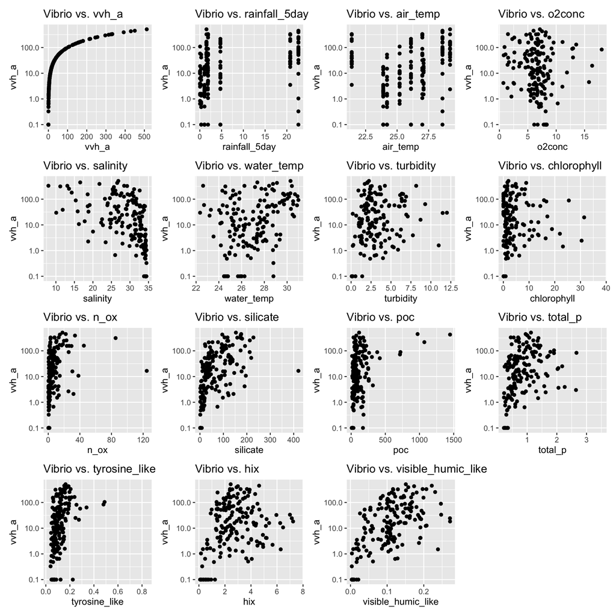

```r
combined_plot <- wrap_plots(plots, ncol = 4)  # 4 columns × 4 rows
combined_plot
```

## Single Model Predictor

*Start by making single-predictor models for each of the 14 predictors listed above.* *Which predictors, on their own, best explain V. vulnificus concentration? If you make an AIC table of the 14 models, what do the Akaike weights look like? What does this mean?* *Note that in order to compare models by AIC each model needs to use the same set of samples (rows) – this means you should remove any rows that include NAs for any of the 14 predictors, or for the response variable, before fitting any of the models.* *What is the downside of using only single-predictor models in this context?*

```r
alawai2<- alawai2 %>% na.omit()
```

```r
mod_a <- lm(log10(vvh_a) ~ rainfall_5day, data = alawai2)
mod_b <- lm(log10(vvh_a) ~ air_temp, data = alawai2)
mod_c <- lm(log10(vvh_a) ~ o2conc, data = alawai2)
mod_d <- lm(log10(vvh_a) ~ salinity, data = alawai2)
mod_e <- lm(log10(vvh_a) ~ water_temp, data = alawai2)
mod_f <- lm(log10(vvh_a) ~ turbidity, data = alawai2)
mod_g <- lm(log10(vvh_a) ~ chlorophyll, data = alawai2)
mod_h <- lm(log10(vvh_a) ~ n_ox, data = alawai2)
mod_i <- lm(log10(vvh_a) ~ silicate, data = alawai2)
mod_j <- lm(log10(vvh_a) ~ poc, data = alawai2)
mod_k <- lm(log10(vvh_a) ~ total_p, data = alawai2)
mod_l <- lm(log10(vvh_a) ~ tyrosine_like, data = alawai2)
mod_m <- lm(log10(vvh_a) ~ hix, data = alawai2)
mod_n <- lm(log10(vvh_a) ~ visible_humic_like, data = alawai2)
```

```r
summary(mod_n)
```

```
##
## Call:
## lm(formula = log10(vvh_a) ~ visible_humic_like, data = alawai2)
##
## Residuals:
##      Min       1Q   Median       3Q      Max
## -2.06074 -0.59223 -0.00015  0.58809  1.33354
##
## Coefficients:
##                    Estimate Std. Error t value Pr(>|t|)
## (Intercept)          0.1941     0.1276   1.521     0.13
## visible_humic_like   8.5661     1.0383   8.250 6.99e-14 ***
## ---
## Signif. codes:  0 '***' 0.001 '**' 0.01 '*' 0.05 '.' 0.1 ' ' 1
##
## Residual standard error: 0.7813 on 152 degrees of freedom
## Multiple R-squared:  0.3093, Adjusted R-squared:  0.3048
## F-statistic: 68.07 on 1 and 152 DF,  p-value: 6.99e-14
```

```r
#mod_a, b, d,e, f, h, i, j, k,l, m,n
# All parameters except O2 concentration and chlorophyll are significantly associated with Vibrio.
```

```r
aic_table <- model.sel(mod_a,mod_b,mod_c ,mod_d ,mod_e ,mod_f ,
                       mod_g ,mod_h ,mod_i ,mod_j , mod_k, mod_l,
                       mod_m, mod_n)
aic_table
```

```
## Model selection table
##         (Int) rnf_5dy air_tmp      o2c      sln wtr_tmp    trb      chl    n_ox
## mod_n  0.1941
## mod_i  0.5777
## mod_d  3.4030                          -0.07975
## mod_a  0.8310 0.05084
## mod_b -3.6330          0.1819
## mod_k  0.4506
## mod_l  0.4511
## mod_e -4.1240                                    0.1938
## mod_j  0.8827
## mod_h  0.9549                                                           0.01988
## mod_f  0.7772                                           0.1039
## mod_m  0.7273
## mod_c  1.2630                 -0.02301
## mod_g  1.0720                                                  0.008778
##            slc      poc  ttl_p tyr_lik    hix vsb_hmc_lik df   logLik  AICc
## mod_n                                               8.566  3 -179.509 365.2
## mod_i 0.007732                                             3 -182.310 370.8
## mod_d                                                      3 -187.474 381.1
## mod_a                                                      3 -191.625 389.4
## mod_b                                                      3 -192.648 391.5
## mod_k                   0.7551                             3 -193.646 393.5
## mod_l                            5.627                     3 -193.792 393.7
## mod_e                                                      3 -193.928 394.0
## mod_j          0.001867                                    3 -197.088 400.3
## mod_h                                                      3 -200.830 407.8
## mod_f                                                      3 -202.929 412.0
## mod_m                                  0.1408              3 -203.919 414.0
## mod_c                                                      3 -207.651 421.5
## mod_g                                                      3 -207.773 421.7
##       delta weight
## mod_n  0.00  0.942
## mod_i  5.60  0.057
## mod_d 15.93  0.000
## mod_a 24.23  0.000
## mod_b 26.28  0.000
## mod_k 28.27  0.000
## mod_l 28.57  0.000
## mod_e 28.84  0.000
## mod_j 35.16  0.000
## mod_h 42.64  0.000
## mod_f 46.84  0.000
## mod_m 48.82  0.000
## mod_c 56.28  0.000
## mod_g 56.53  0.000
## Models ranked by AICc(x)
```

### Interpretation

- Most of the weight is in model for visible humic like material suggesting that that variable is most correlated with the presence of Vibrio.
- Single variable models give the impression that all the variables are able to explain the presence of Vibrio in the Alawai. But when we look at the models together, some of the variables are more heavily associated with Vibrio.

## All inclusive model

*Now make one big model that contains all 14 predictors. Do marginal null hypothesis tests on the predictors. Which seem important for explaining V. vulnificus? Collectively, how much variation in V. vulnificus concentration can be explained? What is a potential downside of this approach to inference (i.e., one big model with marginal tests)?*

```r
model1 <- lm(log10(vvh_a) ~ rainfall_5day+ air_temp+ o2conc+ salinity+ water_temp+ turbidity+ chlorophyll+ n_ox+ silicate+ poc+ total_p+ tyrosine_like+ hix+visible_humic_like, data = alawai2)
```

```r
summary(model1)
```

```
##
## Call:
## lm(formula = log10(vvh_a) ~ rainfall_5day + air_temp + o2conc +
##     salinity + water_temp + turbidity + chlorophyll + n_ox +
##     silicate + poc + total_p + tyrosine_like + hix + visible_humic_like,
##     data = alawai2)
##
## Residuals:
##      Min       1Q   Median       3Q      Max
## -1.34110 -0.45138  0.01895  0.48446  1.44184
##
## Coefficients:
##                      Estimate Std. Error t value Pr(>|t|)
## (Intercept)        -1.7838473  0.9331352  -1.912  0.05798 .
## rainfall_5day       0.0284990  0.0090846   3.137  0.00208 **
## air_temp            0.0653397  0.0489449   1.335  0.18407
## o2conc             -0.0229043  0.0215281  -1.064  0.28921
## salinity           -0.0358246  0.0192372  -1.862  0.06468 .
## water_temp          0.0646338  0.0631843   1.023  0.30811
## turbidity           0.0318730  0.0253572   1.257  0.21088
## chlorophyll        -0.0068177  0.0130494  -0.522  0.60219
## n_ox               -0.0106263  0.0062540  -1.699  0.09153 .
## silicate            0.0053151  0.0016797   3.164  0.00191 **
## poc                 0.0004010  0.0003507   1.143  0.25483
## total_p             0.2900268  0.1677755   1.729  0.08609 .
## tyrosine_like      -1.2201423  1.5252894  -0.800  0.42511
## hix                -0.0877488  0.0930849  -0.943  0.34748
## visible_humic_like  1.8206575  2.8534799   0.638  0.52449
## ---
## Signif. codes:  0 '***' 0.001 '**' 0.01 '*' 0.05 '.' 0.1 ' ' 1
##
## Residual standard error: 0.627 on 139 degrees of freedom
## Multiple R-squared:  0.5932, Adjusted R-squared:  0.5522
## F-statistic: 14.48 on 14 and 139 DF,  p-value: < 2.2e-16
```

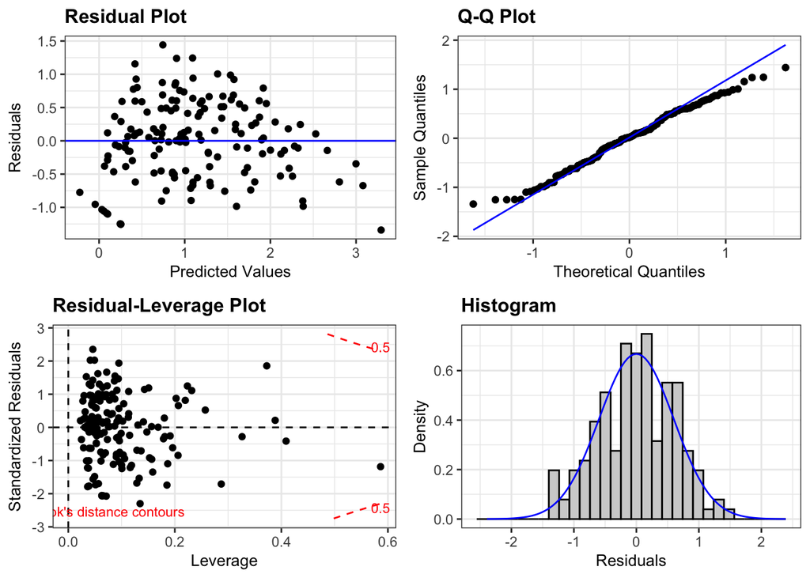

```r
resid_panel(model1, plots = c("resid", "qq", "lev", "hist"))
```

```r
Anova(model1)
```

```
## Anova Table (Type II tests)
##
## Response: log10(vvh_a)
##                    Sum Sq  Df F value   Pr(>F)
## rainfall_5day       3.869   1  9.8413 0.002083 **
## air_temp            0.701   1  1.7821 0.184071
## o2conc              0.445   1  1.1319 0.289208
## salinity            1.363   1  3.4680 0.064679 .
## water_temp          0.411   1  1.0464 0.308113
## turbidity           0.621   1  1.5799 0.210877
## chlorophyll         0.107   1  0.2730 0.602186
## n_ox                1.135   1  2.8870 0.091535 .
## silicate            3.937   1 10.0130 0.001910 **
## poc                 0.514   1  1.3074 0.254830
## total_p             1.175   1  2.9883 0.086090 .
## tyrosine_like       0.252   1  0.6399 0.425110
## hix                 0.349   1  0.8886 0.347483
## visible_humic_like  0.160   1  0.4071 0.524492
## Residuals          54.650 139
## ---
## Signif. codes:  0 '***' 0.001 '**' 0.01 '*' 0.05 '.' 0.1 ' ' 1
```

```r
#marginal null hypothesis test
```

### Interpretation

- According to the Anova, The 5 day rainfall and the silicate variables are the most important variables associated with Vibrio.
- It is possible that adding all these variables in one model “dilutes” the pattern and the contribution of other variables.

### Sum of weight

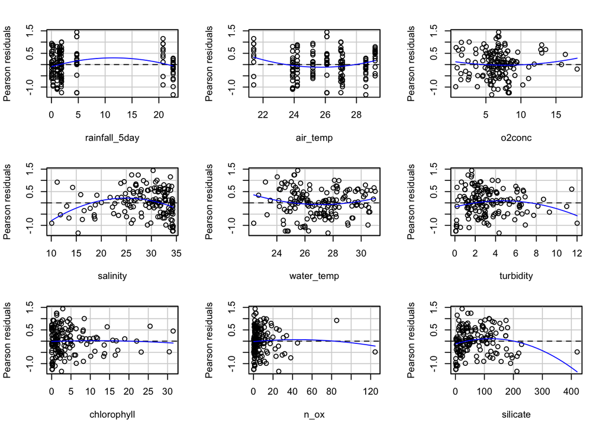

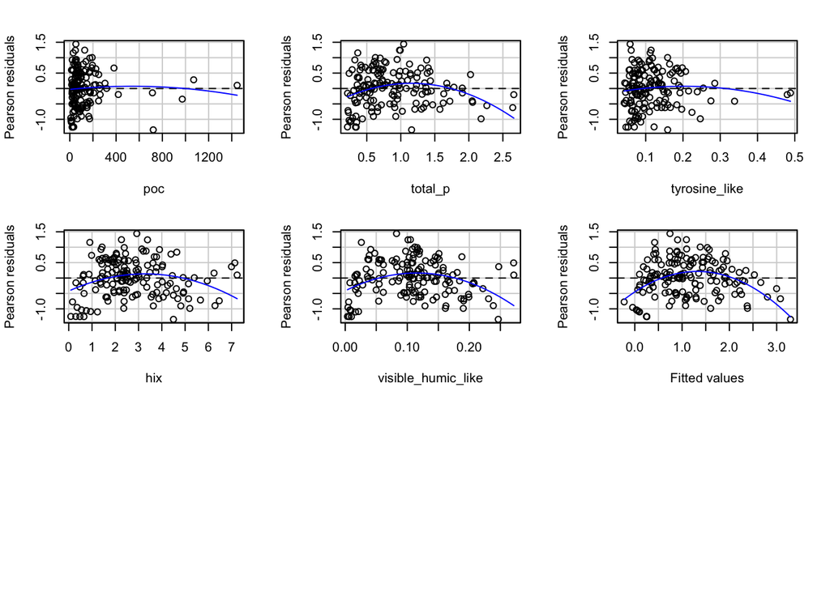

```
##                    Test stat Pr(>|Test stat|)
## rainfall_5day        -1.6288        0.1056359
## air_temp              4.2475        3.951e-05 ***
## o2conc                1.1635        0.2466360
## salinity             -4.5269        1.281e-05 ***
## water_temp            1.9313        0.0554975 .
## turbidity            -2.4862        0.0141053 *
## chlorophyll          -0.3172        0.7515776
## n_ox                 -0.6617        0.5092633
## silicate             -3.7334        0.0002754 ***
## poc                  -0.7069        0.4807904
## total_p              -4.5546        1.143e-05 ***
## tyrosine_like        -1.6854        0.0941682 .
## hix                  -4.2067        4.638e-05 ***
## visible_humic_like   -6.1695        7.142e-09 ***
## Tukey test           -6.6346        3.253e-11 ***
## ---
## Signif. codes:  0 '***' 0.001 '**' 0.01 '*' 0.05 '.' 0.1 ' ' 1
```

```r
residualPlots(model1)
```

```r
model2 <- lm(log10(vvh_a) ~ log10(rainfall_5day) + air_temp+ o2conc+ sqrt(salinity) + water_temp+ log10(turbidity)+ log10(chlorophyll)+ log10(n_ox)+ log10(silicate) + log10(poc)+ total_p+ log10(tyrosine_like)+ hix+visible_humic_like, data = alawai2, na.action = na.fail)
```

```r
summary(model2)
```

```
##
## Call:
## lm(formula = log10(vvh_a) ~ log10(rainfall_5day) + air_temp +
##     o2conc + sqrt(salinity) + water_temp + log10(turbidity) +
##     log10(chlorophyll) + log10(n_ox) + log10(silicate) + log10(poc) +
##     total_p + log10(tyrosine_like) + hix + visible_humic_like,
##     data = alawai2, na.action = na.fail)
##
## Residuals:
##     Min      1Q  Median      3Q     Max
## -1.3151 -0.3188 -0.0101  0.2866  1.0394
##
## Coefficients:
##                      Estimate Std. Error t value Pr(>|t|)
## (Intercept)           0.21280    0.92576   0.230 0.818533
## log10(rainfall_5day)  0.37540    0.06418   5.849 3.38e-08 ***
## air_temp              0.14345    0.03743   3.833 0.000191 ***
## o2conc               -0.01954    0.01596  -1.225 0.222796
## sqrt(salinity)        0.19992    0.13830   1.446 0.150550
## water_temp           -0.21578    0.05379  -4.012 9.80e-05 ***
## log10(turbidity)      0.43493    0.12081   3.600 0.000441 ***
## log10(chlorophyll)   -0.05413    0.07468  -0.725 0.469822
## log10(n_ox)           0.14704    0.15142   0.971 0.333175
## log10(silicate)       1.05643    0.16409   6.438 1.83e-09 ***
## log10(poc)            0.25556    0.16531   1.546 0.124393
## total_p               0.11621    0.11122   1.045 0.297873
## log10(tyrosine_like)  0.29813    0.45515   0.655 0.513540
## hix                  -0.13213    0.08621  -1.533 0.127633
## visible_humic_like    1.44680    2.30126   0.629 0.530579
## ---
## Signif. codes:  0 '***' 0.001 '**' 0.01 '*' 0.05 '.' 0.1 ' ' 1
##
## Residual standard error: 0.4809 on 139 degrees of freedom
## Multiple R-squared:  0.7608, Adjusted R-squared:  0.7367
## F-statistic: 31.57 on 14 and 139 DF,  p-value: < 2.2e-16
```

```r
model2_dredge <- dredge(model2)
```

```r
sw(model2_dredge)
```

```
##                      log10(silicate) log10(rainfall_5day) log10(turbidity)
## Sum of weights:      1.00            1.00                 1.00
## N containing models: 8192            8192                 8192
##                      air_temp water_temp hix  log10(tyrosine_like) log10(poc)
## Sum of weights:      1.00     1.00       0.75 0.65                 0.53
## N containing models: 8192     8192       8192 8192                 8192
##                      sqrt(salinity) visible_humic_like o2conc total_p
## Sum of weights:      0.48           0.42               0.39   0.37
## N containing models: 8192           8192               8192   8192
##                      log10(n_ox) log10(chlorophyll)
## Sum of weights:      0.32        0.28
## N containing models: 8192        8192
```

### Interpretation

- silica, rainfall, turbidity, air temp, and water temp are the most associated variation with a sum of weight equal to 1, when the variables are log10.

## Best model

```r
model3 <- lm(log10(vvh_a) ~ log10(rainfall_5day) + air_temp+ water_temp+ log10(turbidity)+  log10(silicate), data = alawai)
```

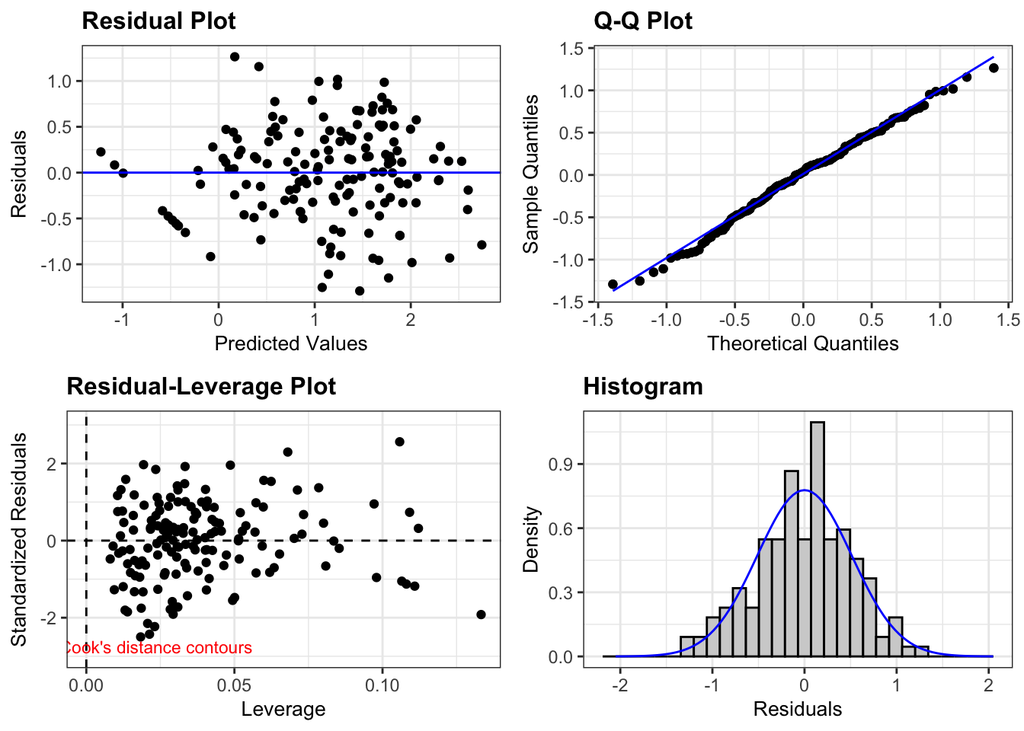

```r
resid_panel(model3, plots = c("resid", "qq", "lev", "hist"))
```

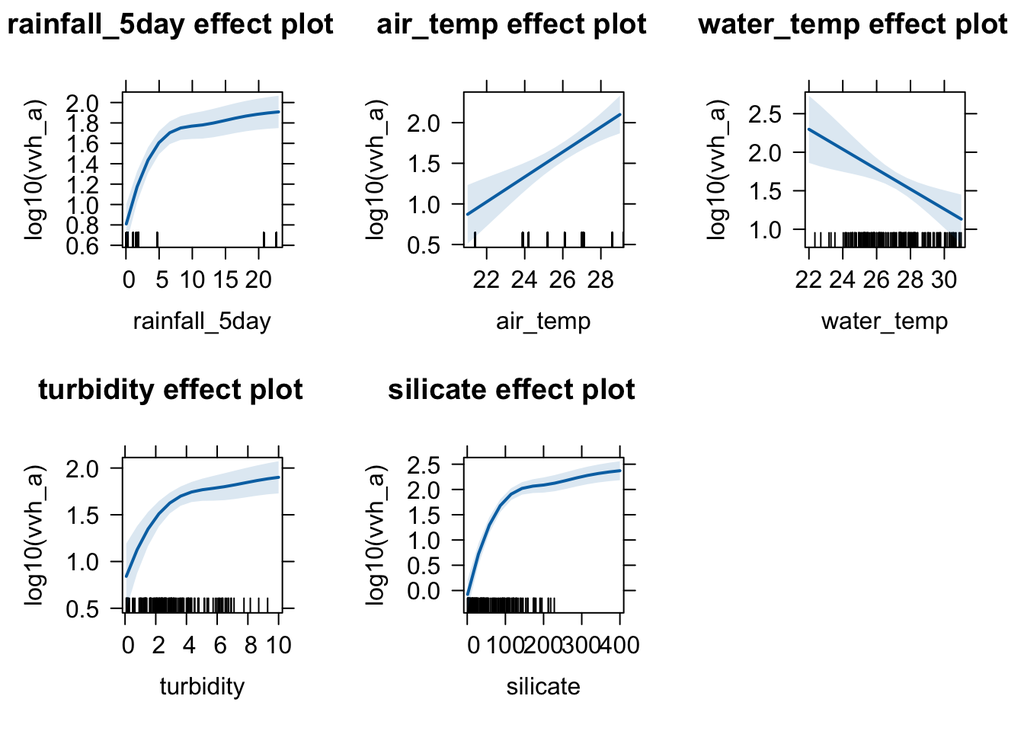

```r
plot(allEffects(model3))
```

### Interpretation

- The mechanisms for the presence of Vibrio could be the following:
- Typically, higher air temperature causes lower pressure systems to form about the island which results in rainfall. Increased rainfall washes Vibrio on land into the ala wai. Runoffs cause the turbidity to increase. Increased water on land may cause a surge of groundwater wish explains the higher concentration of silicate in the water. Added freshwater in the ala wai causes water temperature to decrease.